```python
import pandas as pd
from matplotlib import pyplot as plt
from sklearn import linear_model, datasets
from sklearn.preprocessing import PolynomialFeatures
from sklearn import tree
from sklearn.ensemble import RandomForestClassifier
from sklearn.metrics import accuracy_score, recall_score
import statsmodels.formula.api as smf
import sklearn.model_selection as ms
```

```python
df = pd.read_csv("mirror/08_gap-every-five-years.tsv", sep='\t')
df.head()
```

|  | country | continent | year | lifeExp | pop | gdpPercap |
| --- | --- | --- | --- | --- | --- | --- |
| 0 | Afghanistan | Asia | 1952 | 28.801 | 8425333 | 779.445314 |
| 1 | Afghanistan | Asia | 1957 | 30.332 | 9240934 | 820.853030 |
| 2 | Afghanistan | Asia | 1962 | 31.997 | 10267083 | 853.100710 |
| 3 | Afghanistan | Asia | 1967 | 34.020 | 11537966 | 836.197138 |
| 4 | Afghanistan | Asia | 1972 | 36.088 | 13079460 | 739.981106 |

# Part 1

## Excercise 1

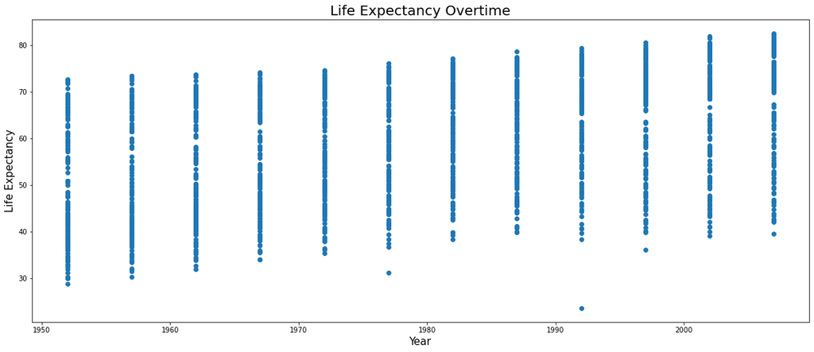

```python
plt.figure(figsize=(20,8))
plt.title('Life Expectancy Overtime', fontsize = 20)
plt.xlabel('Year', fontsize = 15)
plt.ylabel('Life Expectancy', fontsize = 15)
plt.scatter(df['year'], df['lifeExp'])
```

The graph shows the life expectancy of every country per year.

## Question 1

Life expectancy does look to increase overtime as the highest datapoint of each year is usually higher than the year before and the same is seen for the lowest datapoint for each year is usually higher than the year before. This increase looks to be linear because it seems like the majority of datapoints for each year move up at a constant rate.

```python
years = df['year'].unique()
split_year = df.groupby('year')

lifeExp_year = []
for group in split_year:
    lifeExp_year.append(group[1]['lifeExp'].array)
```

```
{'bodies': [<matplotlib.collections.PolyCollection at 0x7f2a5706d1f0>,
 'cmeans': <matplotlib.collections.LineCollection at 0x7f2a57059f70>,
 'cmaxes': <matplotlib.collections.LineCollection at 0x7f2a57086a00>,
 'cmins': <matplotlib.collections.LineCollection at 0x7f2a57086f10>,
 'cbars': <matplotlib.collections.LineCollection at 0x7f2a5701c460>}
```

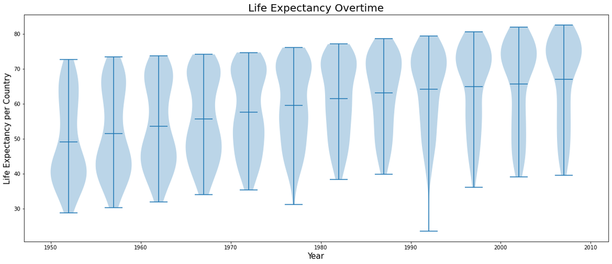

```python
plt.figure(figsize=(20,8))
plt.title('Life Expectancy Overtime', fontsize = 20)
plt.xlabel('Year', fontsize = 15)
plt.ylabel('Life Expectancy per Country', fontsize = 15)
plt.violinplot(lifeExp_year, years, widths=4, showmeans=True)
```

The above violin plot that displays a violin distribution of countries life expectancy's per year.

## Question 2

Based on the violin plot there seems to be different distribution for life expectancy depending on the year. Some violin plots can be grouped together for their similarity in distribution. For years between 1950 to 1960, the life Expectancy was skewed towards the higher age meaning majority of countries had a lower than median life expectancy. For years between 1960 to 1975, the distribution seems symmetric around the center. There are about as many countries that have a lower than average life expectancy as there are countries higher than the average during these years. For every year past 1975, the distribution is skewed towards the lower ages meaning that majority of countries had a life expectancy greater than the average. There is a very noticable outlier in the plot, 1992, where one country had a extremely low life expectancy compared to the other countries and even years. This could likely be due to a disease or war that wiped out lots of the population.

## Question 3

I would reject the null hypothesis based on plot I made. The center of each violin is higher than the year before it. This is a noticable increase in the average life expectancy overtime that it would be surprising if there was no relationship between the two.

## Question 4

I think a violin plot for the residuals would look pretty similar to the one for life expectancy. If we were to put a linear regression on the previous violin plot then I believe the line would end up close to where the centers of each violin plot. Since the line is close to the centers, if we were to take the residuals of each violin plot then the distribution would stay the same. The sides where there are more countries distributed in the violin plot would still have a higher distribution of countries in the residuals plot.

## Question 5

The violin plot should have the mean/center of each year's violin be centered at 0. The overall distribution of the violin as in the shape of the violin should have the center be the widest and as you go towards the ends of the violin it will become thinner and thinner. This means, like a bell shape curve, the center has the highest count of residuals and as you head towards both ends the amount of residuals will similarly decrease. This ideal violin plot is created on the assumptoins that residuals are independent from one another, the variance of residuals is constant, and that residuals are normally distributed.

## Exercise 2

To create a linear model I created a 2d array where each index is an array that contains the year of one data point. It's done this way because lm.fit only accepts 2d arrays for its first parameter.

```python
year = [[x] for x in df['year']]
lifeExp = df['lifeExp']
```

```python
lm = linear_model.LinearRegression()
lm.fit(year, lifeExp)
```

```
LinearRegression()
```

```python
print("Linear model coefficient =", lm.coef_[0])
print("Linear model y-intercept =", lm.intercept_)
print("lifeExp =", lm.coef_[0], "*year ", lm.intercept_)
```

```
Linear model coefficient = 0.3259038276371518
Linear model y-intercept = -585.6521874415448
lifeExp = 0.3259038276371518 *year  -585.6521874415448
```

## Question 6

Around 1/3 of a year since the coefficient of the linear model is 0.3259 which can be rounded up to 0.33

## Question 7

Yes, I do reject the null hypothesis because my linear regression model shows me that there is an increase in life expectancy every year. If my null hypothesis is true and there is no relationship between year and life expectancy, then my linear model should have a coefficient of 0 meaning no relationship. But since the coeffiient is not 0, that means the null hypothesis is likely incorrect.

## Exercise 3

I use the created linear model to predict what the supposed life expectancy of a year should be and subtract this predicted life expectancy from the actual life expectancy of the dataset to get the residuals. I then group these residuals by year to create the violin plot.

```python
predictions = lm.predict(year)
residuals = []

for i in range(len(lifeExp)):
    residuals.append(lifeExp[i] - predictions[i])
```

```python
df['residual_lifeExp'] = residuals
split_year = df.groupby('year')

lifeExp_residual = []
for group in split_year:
    lifeExp_residual.append(group[1]['residual_lifeExp'].array)
```

```
{'bodies': [<matplotlib.collections.PolyCollection at 0x7f2a56f62190>,
 'cmeans': <matplotlib.collections.LineCollection at 0x7f2a56f51f40>,
 'cmaxes': <matplotlib.collections.LineCollection at 0x7f2a56f799d0>,
 'cmins': <matplotlib.collections.LineCollection at 0x7f2a56f79ee0>,
 'cbars': <matplotlib.collections.LineCollection at 0x7f2a56f0d430>}
```

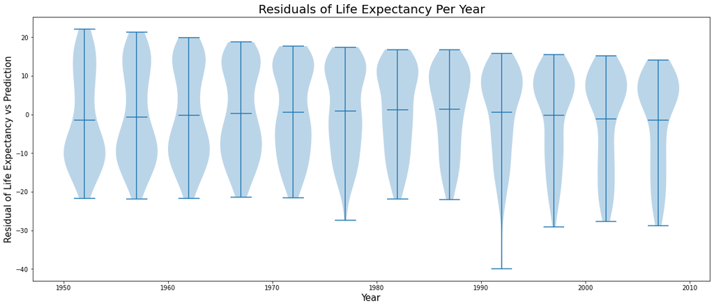

```python
plt.figure(figsize=(20,8))
plt.title('Residuals of Life Expectancy Per Year', fontsize = 20)
plt.xlabel('Year', fontsize = 15)
plt.ylabel('Residual of Life Expectancy vs Prediction', fontsize = 15)
plt.violinplot(lifeExp_residual, years, widths=4, showmeans=True)
```

The above violin plot shows the distribution of the residual life expectancy of every country by year.

## Question 8

Yes the violin plot did match my expectations as I correctly predicted the shapes of each violin. The only thing I didn't expect or think about was the where exactly the mean of each violin plot would be centered at which in this case is around 0. This makes sense since the residuals are calculated by comparing a life expectancy to the predicted life expectancy for the year. So since all life expectancy revolve around one value per year that makes the residual's mean be around one number which is 0 in this case.

## Exercise 4

I group the dataset by continents using groupby and use the residuals from each continent to produce a boxplot.

```python
split_continent = df.groupby('continent')
lifeExp_continent = []

for group in split_continent:
    lifeExp_continent.append(group[1]['residual_lifeExp'].array)
```

I grab the names of each continent and sort them in increasing order to match the order the lifeExp_continent 2d array stores the data

```python
continents = df['continent'].unique()
continents.sort()
```

[output not shown]

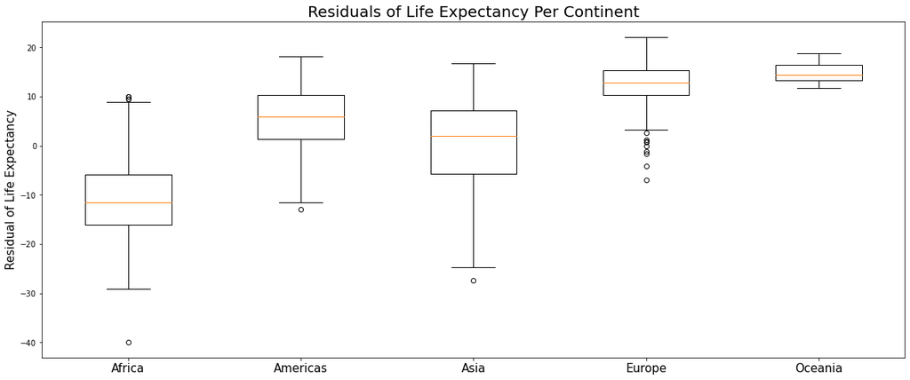

```python
plt.figure(figsize=(20,8))
plt.title('Residuals of Life Expectancy Per Continent', fontsize = 20)
plt.ylabel('Residual of Life Expectancy', fontsize = 15)
plt.boxplot(lifeExp_continent)
plt.xticks([1, 2, 3, 4, 5], continents, fontsize = 15)
```

## Exercise 5

To graph each continents life expectancy overtime I grabbed the each continents dataset from the grouped dataset I made in exercise 4. I then calculate a linear model for each continent. Then I plot every countries life expectancy per year for the continent and plot the linear model to see each continents linear regression.

```python
africa_df = split_continent.get_group('Africa').copy()
americas_df = split_continent.get_group('Americas').copy()
asia_df = split_continent.get_group('Asia').copy()
europe_df = split_continent.get_group('Europe').copy()
oceania_df = split_continent.get_group('Oceania').copy()
```

```python
ind = [[x] for x in africa_df['year']]
dep = africa_df['lifeExp']
lm = linear_model.LinearRegression()
lm.fit(ind,dep)
```

```
LinearRegression()
```

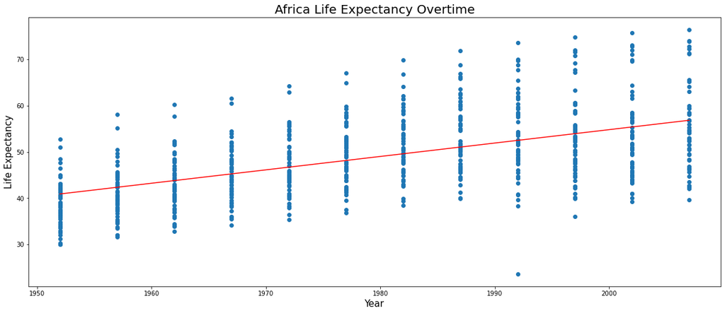

```python
plt.figure(figsize=(20,8))
plt.title('Africa Life Expectancy Overtime', fontsize = 20)
plt.xlabel('Year', fontsize = 15)
plt.ylabel('Life Expectancy', fontsize = 15)
plt.scatter(africa_df['year'], africa_df['lifeExp'])
plt.plot(ind, lm.predict(ind), color='red')
```

```python
ind = [[x] for x in americas_df['year']]
dep = americas_df['lifeExp']
lm = linear_model.LinearRegression()
lm.fit(ind,dep)
```

```
LinearRegression()
```

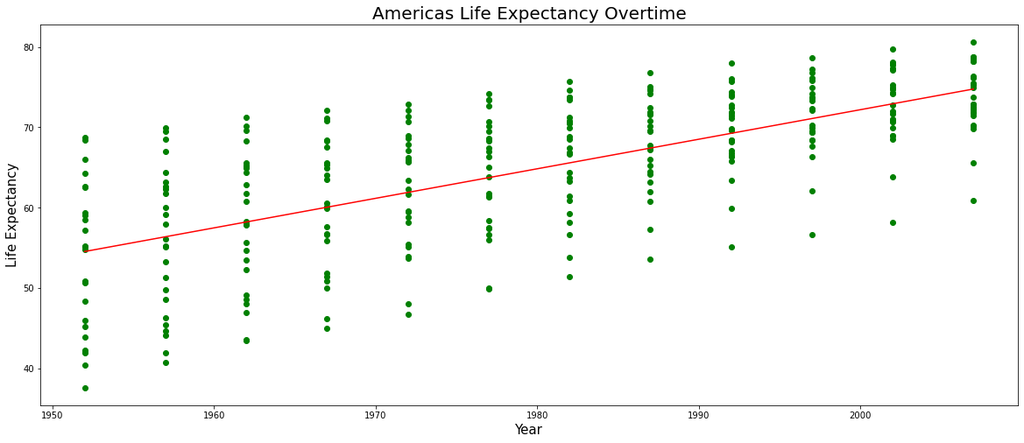

```python
plt.figure(figsize=(20,8))
plt.title('Americas Life Expectancy Overtime', fontsize = 20)
plt.xlabel('Year', fontsize = 15)
plt.ylabel('Life Expectancy', fontsize = 15)
plt.scatter(americas_df['year'], americas_df['lifeExp'], color = 'green')
plt.plot(ind, lm.predict(ind), color='red')
```

```python
ind = [[x] for x in asia_df['year']]
dep = asia_df['lifeExp']
lm = linear_model.LinearRegression()
lm.fit(ind,dep)
```

```
LinearRegression()
```

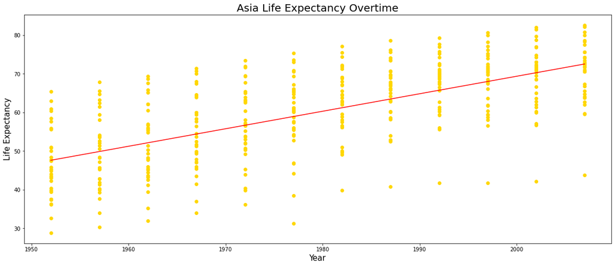

```python
plt.figure(figsize=(20,8))
plt.title('Asia Life Expectancy Overtime', fontsize = 20)
plt.xlabel('Year', fontsize = 15)
plt.ylabel('Life Expectancy', fontsize = 15)
plt.scatter(asia_df['year'], asia_df['lifeExp'], color = 'gold')
plt.plot(ind, lm.predict(ind), color='red')
```

```python
ind = [[x] for x in europe_df['year']]
dep = europe_df['lifeExp']
lm = linear_model.LinearRegression()
lm.fit(ind,dep)
```

```
LinearRegression()
```

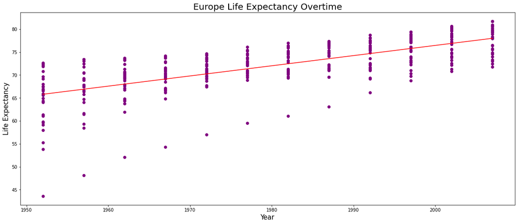

```python
plt.figure(figsize=(20,8))
plt.title('Europe Life Expectancy Overtime', fontsize = 20)
plt.xlabel('Year', fontsize = 15)
plt.ylabel('Life Expectancy', fontsize = 15)
plt.scatter(europe_df['year'], europe_df['lifeExp'], color = 'purple')
plt.plot(ind, lm.predict(ind), color='red')
```

```python
ind = [[x] for x in oceania_df['year']]
dep = oceania_df['lifeExp']
lm = linear_model.LinearRegression()
lm.fit(ind,dep)
```

```
LinearRegression()
```

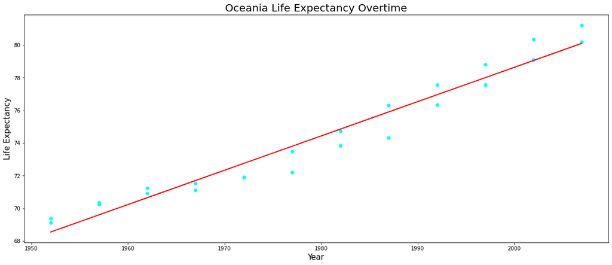

```python
plt.figure(figsize=(20,8))
plt.title('Oceania Life Expectancy Overtime', fontsize = 20)
plt.xlabel('Year', fontsize = 15)
plt.ylabel('Life Expectancy', fontsize = 15)
plt.scatter(oceania_df['year'], oceania_df['lifeExp'], color = 'cyan')
plt.plot(ind, lm.predict(ind), color='red')
```

## Exercise 6

I used the statsmodel library to create a regression with an interaction between continent and year.

```python
lm = smf.ols("lifeExp ~ continent * year", df).fit()
coeff = lm.params
```

```python
print(f"Africa coeff: {coeff[5]}")
print(f"Americas coeff: {coeff[6]}")
print(f"Asia coeff: {coeff[7]}")
print(f"Europe coeff: {coeff[8]}")
print(f"Oceania coeff: {coeff[9]}")
```

```
Africa coeff: 0.28952926304617876
Americas coeff: 0.07812167401843138
Asia coeff: 0.16359314085441587
Europe coeff: -0.06759711852245037
Oceania coeff: -0.07925688542218916
```

## Question 11

```python
print(lm.summary())
```

```
                            OLS Regression Results
==============================================================================
Dep. Variable:                lifeExp   R-squared:                       0.693
Model:                            OLS   Adj. R-squared:                  0.691
Method:                 Least Squares   F-statistic:                     424.3
Date:                Thu, 28 Apr 2022   Prob (F-statistic):               0.00
Time:                        04:05:44   Log-Likelihood:                -5771.9
No. Observations:                1704   AIC:                         1.156e+04
Df Residuals:                    1694   BIC:                         1.162e+04
Df Model:                           9
Covariance Type:            nonrobust
==============================================================================================
                                 coef    std err          t      P>|t|      [0.025      0.975]
----------------------------------------------------------------------------------------------
Intercept                   -524.2578     32.963    -15.904      0.000    -588.911    -459.605
continent[T.Americas]       -138.8484     57.851     -2.400      0.016    -252.315     -25.382
continent[T.Asia]           -312.6330     52.904     -5.909      0.000    -416.396    -208.870
continent[T.Europe]          156.8469     54.498      2.878      0.004      49.957     263.737
continent[T.Oceania]         182.3499    171.283      1.065      0.287    -153.599     518.298
year                           0.2895      0.017     17.387      0.000       0.257       0.322
continent[T.Americas]:year     0.0781      0.029      2.673      0.008       0.021       0.135
continent[T.Asia]:year         0.1636      0.027      6.121      0.000       0.111       0.216
continent[T.Europe]:year      -0.0676      0.028     -2.455      0.014      -0.122      -0.014
continent[T.Oceania]:year     -0.0793      0.087     -0.916      0.360      -0.249       0.090
==============================================================================
Omnibus:                       27.121   Durbin-Watson:                   0.242
Prob(Omnibus):                  0.000   Jarque-Bera (JB):               44.106
Skew:                          -0.121   Prob(JB):                     2.65e-10
Kurtosis:                       3.750   Cond. No.                     2.09e+06
==============================================================================

Notes:
[1] Standard Errors assume that the covariance matrix of the errors is correctly specified.
[2] The condition number is large, 2.09e+06. This might indicate that there are
strong multicollinearity or other numerical problems.
```

Africa was used as the reference for how to calculate all the other continent's parameters so it's parameters aren't labeled in the summary.

## Question 12

I created a prediction function that takes in a continent where 0 is Africa, 1 Americas, 2 Asia, 3 Europe, & 4 Oceania and a year and returns the predicted life expectancy of that continent in that year. lm.params contains the y-intercepts of each continent in indicies 0 upto len(lm.params/2) - 1 and the coefficients from len(lm.params/2) upto the end of the array.

```python
def predict_life(continent, year):
    return lm.params[continent + int(len(lm.params)/2)] * year + lm.params[continent]
```

```python
africa_90 = predict_life(0, 1990)
africa_91 = predict_life(0, 1991)
print(f"Africa   Life Expectancy: 1990 = {africa_90}, 1991 = {africa_91}, Diff = {africa_91 - africa_90}")

merica_90 = predict_life(1, 1990)
merica_91 = predict_life(1, 1991)
print(f"Americas Life Expectancy: 1990 = {merica_90}, 1991 = {merica_91}, Diff = {merica_91 - merica_90}")

asia_90 = predict_life(2, 1990)
asia_91 = predict_life(2, 1991)
print(f"Asia     Life Expectancy: 1990 = {asia_90}, 1991 = {asia_91}, Diff = {asia_91 - asia_90}")

euro_90 = predict_life(3, 1990)
euro_91 = predict_life(3, 1991)
print(f"Europe   Life Expectancy: 1990 = {euro_90}, 1991 = {euro_91}, Diff = {euro_91 - euro_90}")

ocean_90 = predict_life(4, 1990)
ocean_91 = predict_life(4, 1991)
print(f"Oceania  Life Expectancy: 1990 = {ocean_90}, 1991 = {ocean_91}, Diff = {ocean_91 - ocean_90}")
```

```
Africa   Life Expectancy: 1990 = 51.90538739013891, 1991 = 52.19491665318503, Diff = 0.2895292630461199
Americas Life Expectancy: 1990 = 16.613684115929033, 1991 = 16.691805789947466, Diff = 0.0781216740184334
Asia     Life Expectancy: 1990 = 12.917301083034772, 1991 = 13.080894223889231, Diff = 0.1635931408544593
Europe   Life Expectancy: 1990 = 22.328586238499696, 1991 = 22.26098911997724, Diff = -0.06759711852245687
Oceania  Life Expectancy: 1990 = 24.628680908346723, 1991 = 24.54942402292454, Diff = -0.07925688542218268
```

## Exercise 7

The function below takes in an integer value which represents a continent and a dataframe and returns the predicted life expectancy of every row's year in the dataframe. The continent given is used to see which coefficient from the linear regression will be used to calculate the predicted life expectancy of the given year from the dataframe

```python
def predict_continent(continent, df):
    coef = lm.params[continent + int(len(lm.params)/2)]
    intercept = lm.params[continent]
    prediction = []

    for index, row in df.iterrows():
         prediction.append(coef * row['year'] + intercept)

    return prediction
```

I decided to make a violin plot of the residuals for each continent because I think multiple plots would be much easier to interpret and understand compared to including all contintent violins in one plot. So the code for each violin plot is the same as to what was done in Exercise 3. I only replaced using the data with all continents to data specifically from each continent.

```python
africa_residu = africa_df['lifeExp'] - predict_continent(0, africa_df)

africa_df['residual'] = africa_residu
split_year = africa_df.groupby('year')

lifeExp_residual = []
for group in split_year:
    lifeExp_residual.append(group[1]['residual'].array)
```

```
{'bodies': [<matplotlib.collections.PolyCollection at 0x7f2a56b567c0>,
 'cmeans': <matplotlib.collections.LineCollection at 0x7f2a56b565b0>,
 'cmaxes': <matplotlib.collections.LineCollection at 0x7f2a5426dfd0>,
 'cmins': <matplotlib.collections.LineCollection at 0x7f2a5427d520>,
 'cbars': <matplotlib.collections.LineCollection at 0x7f2a5427da30>}
```

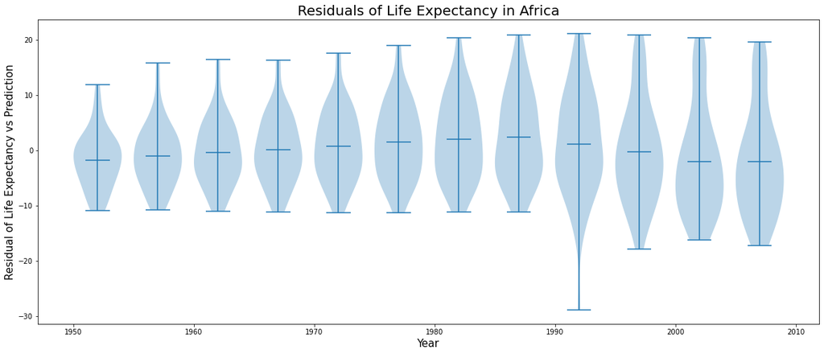

```python
plt.figure(figsize=(20,8))
plt.title('Residuals of Life Expectancy in Africa', fontsize = 20)
plt.xlabel('Year', fontsize = 15)
plt.ylabel('Residual of Life Expectancy vs Prediction', fontsize = 15)
plt.violinplot(lifeExp_residual, years, widths=4, showmeans=True)
```

```python
america_residu = americas_df['lifeExp'] - predict_continent(1, americas_df)

americas_df['residual'] = america_residu
split_year = americas_df.groupby('year')

lifeExp_residual = []
for group in split_year:
    lifeExp_residual.append(group[1]['residual'].array)
```

```
{'bodies': [<matplotlib.collections.PolyCollection at 0x7f2a541df610>,
 'cmeans': <matplotlib.collections.LineCollection at 0x7f2a541df400>,
 'cmaxes': <matplotlib.collections.LineCollection at 0x7f2a541f9e20>,
 'cmins': <matplotlib.collections.LineCollection at 0x7f2a5420c370>,
 'cbars': <matplotlib.collections.LineCollection at 0x7f2a5420c880>}
```

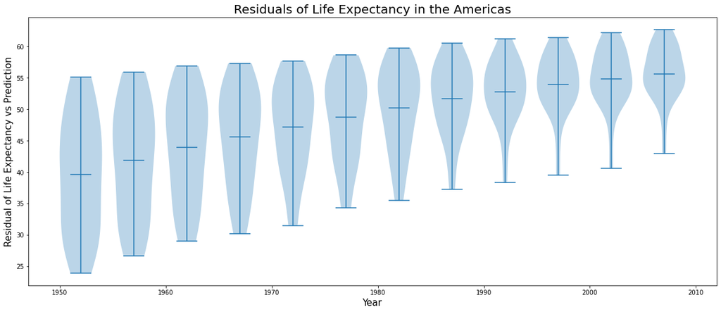

```python
plt.figure(figsize=(20,8))
plt.title('Residuals of Life Expectancy in the Americas', fontsize = 20)
plt.xlabel('Year', fontsize = 15)
plt.ylabel('Residual of Life Expectancy vs Prediction', fontsize = 15)
plt.violinplot(lifeExp_residual, years, widths=4, showmeans=True)
```

```python
asia_residu = asia_df['lifeExp'] - predict_continent(2, asia_df)

asia_df['residual'] = asia_residu
split_year = asia_df.groupby('year')

lifeExp_residual = []
for group in split_year:
    lifeExp_residual.append(group[1]['residual'].array)
```

```
{'bodies': [<matplotlib.collections.PolyCollection at 0x7f2a541be940>,
 'cmeans': <matplotlib.collections.LineCollection at 0x7f2a56e0b040>,
 'cmaxes': <matplotlib.collections.LineCollection at 0x7f2a54117430>,
 'cmins': <matplotlib.collections.LineCollection at 0x7f2a54117940>,
 'cbars': <matplotlib.collections.LineCollection at 0x7f2a54117e50>}
```

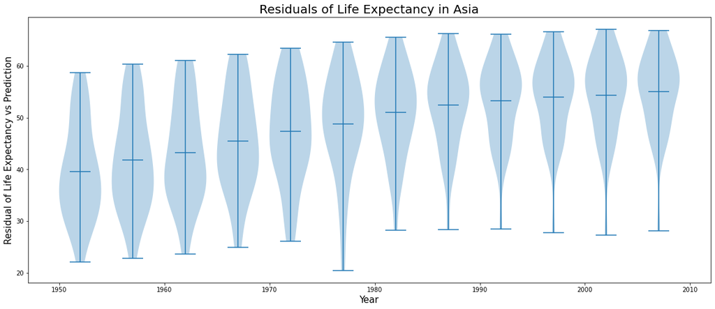

```python
plt.figure(figsize=(20,8))
plt.title('Residuals of Life Expectancy in Asia', fontsize = 20)
plt.xlabel('Year', fontsize = 15)
plt.ylabel('Residual of Life Expectancy vs Prediction', fontsize = 15)
plt.violinplot(lifeExp_residual, years, widths=4, showmeans=True)
```

```python
euro_residu = europe_df['lifeExp'] - predict_continent(3, europe_df)

europe_df['residual'] = euro_residu
split_year = europe_df.groupby('year')

lifeExp_residual = []
for group in split_year:
    lifeExp_residual.append(group[1]['residual'].array)
```

```
{'bodies': [<matplotlib.collections.PolyCollection at 0x7f2a54107220>,
 'cmeans': <matplotlib.collections.LineCollection at 0x7f2a541070a0>,
 'cmaxes': <matplotlib.collections.LineCollection at 0x7f2a540a3a30>,
 'cmins': <matplotlib.collections.LineCollection at 0x7f2a540a3f40>,
 'cbars': <matplotlib.collections.LineCollection at 0x7f2a540b5490>}
```

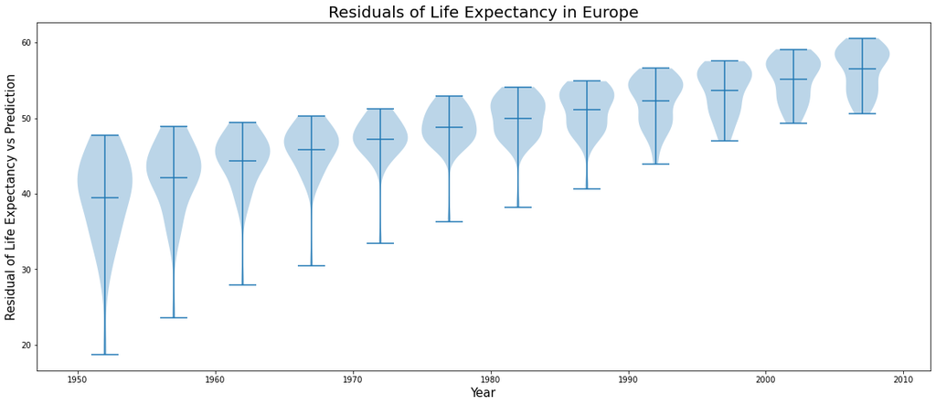

```python
plt.figure(figsize=(20,8))
plt.title('Residuals of Life Expectancy in Europe', fontsize = 20)
plt.xlabel('Year', fontsize = 15)
plt.ylabel('Residual of Life Expectancy vs Prediction', fontsize = 15)
plt.violinplot(lifeExp_residual, years, widths=4, showmeans=True)
```

```python
ocea_residu = oceania_df['lifeExp'] - predict_continent(4, oceania_df)

oceania_df['residual'] = ocea_residu
split_year = oceania_df.groupby('year')

lifeExp_residual = []
for group in split_year:
    lifeExp_residual.append(group[1]['residual'].array)
```

```
{'bodies': [<matplotlib.collections.PolyCollection at 0x7f2a54093880>,
 'cmeans': <matplotlib.collections.LineCollection at 0x7f2a540936a0>,
 'cmaxes': <matplotlib.collections.LineCollection at 0x7f2a54040100>,
 'cmins': <matplotlib.collections.LineCollection at 0x7f2a54040610>,
 'cbars': <matplotlib.collections.LineCollection at 0x7f2a54040b20>}
```

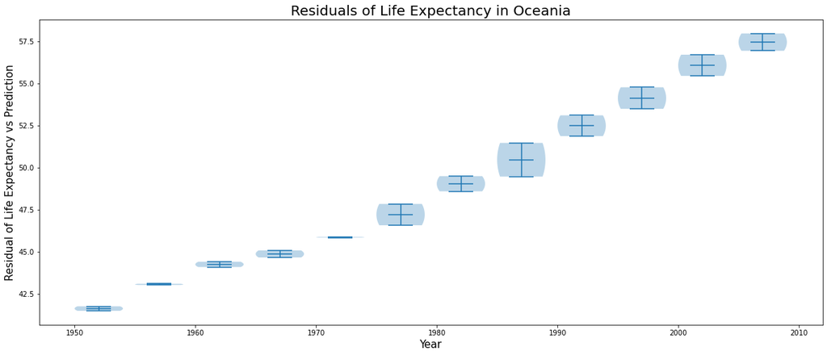

```python
plt.figure(figsize=(20,8))
plt.title('Residuals of Life Expectancy in Oceania', fontsize = 20)
plt.xlabel('Year', fontsize = 15)
plt.ylabel('Residual of Life Expectancy vs Prediction', fontsize = 15)
plt.violinplot(lifeExp_residual, years, widths=4, showmeans=True)
```

# Part 2

I am using the iris dataset which includes 4 attributes of the sepal width & length and the petals width & length as well as the 3 classification of the iris based off its attributes. My models will try to predict which of the 3 classifications a given iris will be given it's attributes.

I decided to compare the decision tree against the random forest model because random forests simply use multiple decision trees when predicting. I wanted to see whether this use of multiple trees would substantially improve prediction accuracy at a cost of using more resources. When comparing the performance of decision trees vs random forests, I will decide which is better at classification by checking their accuracy and recall. I chose these two metrics because accuracy is an easy to understand gauge of how good a model's predictions are and recall helps show how much of the dataset the model was eventually able to accurately predict.

I first grab the iris dataset then change the [0,1,2] classification of the iris to it's target names [setosa, versicolor, virginica] for readability. Then I perform holdout validation by splittng the data into a 80% training set and a 20% test set. I chose this ratio because it the standard which means that it should've been tested to be a good ratio for accuracy.

```python
iris = datasets.load_iris()
iris_target = pd.Categorical.from_codes(iris.target, iris.target_names)
iris_df = pd.DataFrame(data = iris.data, columns = iris.feature_names)
iris_df["target"] = iris_target
iris_df
```

|  | sepal length (cm) | sepal width (cm) | petal length (cm) | petal width (cm) | target |
| --- | --- | --- | --- | --- | --- |
| 0 | 5.1 | 3.5 | 1.4 | 0.2 | setosa |
| 1 | 4.9 | 3.0 | 1.4 | 0.2 | setosa |
| 2 | 4.7 | 3.2 | 1.3 | 0.2 | setosa |
| 3 | 4.6 | 3.1 | 1.5 | 0.2 | setosa |
| 4 | 5.0 | 3.6 | 1.4 | 0.2 | setosa |
| ... | ... | ... | ... | ... | ... |
| 145 | 6.7 | 3.0 | 5.2 | 2.3 | virginica |
| 146 | 6.3 | 2.5 | 5.0 | 1.9 | virginica |
| 147 | 6.5 | 3.0 | 5.2 | 2.0 | virginica |
| 148 | 6.2 | 3.4 | 5.4 | 2.3 | virginica |
| 149 | 5.9 | 3.0 | 5.1 | 1.8 | virginica |

150 rows × 5 columns

```python
ind_train, ind_test, dep_train, dep_test = ms.train_test_split(iris.data, iris_target, test_size = 0.2)
```

I chose to create a decision tree with a depth of 5 because it seems reasonable when looking at the iris dataset. There are 4 attributes to an iris and with a depth of 5, each level in the decision tree can ask a question about one of the 4 attributes which should allow for an accurate classification of each iris.

```python
dt = tree.DecisionTreeClassifier(max_depth = 5)
dt = dt.fit(ind_train, dep_train)
```

I decided to create a random forest madel with 10 decision trees rather than the default 100 because in this scenario there are only 3 possible classifications of iris so anymore than even 5 feels like it would be wasting resources for around the same predictive accuracy.

```python
rf = RandomForestClassifier(n_estimators = 10)
rf = rf.fit(ind_train, dep_train)
```

```python
predict_dt = dt.predict(ind_test)
predict_dt
```

```
array(['setosa', 'versicolor', 'setosa', 'setosa', 'virginica',
       'virginica', 'virginica', 'virginica', 'setosa', 'setosa',
       'setosa', 'setosa', 'virginica', 'setosa', 'virginica',
       'virginica', 'versicolor', 'versicolor', 'virginica', 'setosa',
       'setosa', 'setosa', 'virginica', 'virginica', 'setosa',
       'virginica', 'virginica', 'setosa', 'virginica', 'versicolor'],
      dtype=object)
```

```python
predict_rf = rf.predict(ind_test)
predict_rf
```

```
array(['setosa', 'versicolor', 'setosa', 'setosa', 'virginica',
       'virginica', 'virginica', 'virginica', 'setosa', 'setosa',
       'setosa', 'setosa', 'virginica', 'setosa', 'virginica',
       'virginica', 'versicolor', 'versicolor', 'virginica', 'setosa',
       'setosa', 'setosa', 'virginica', 'virginica', 'setosa',
       'virginica', 'virginica', 'setosa', 'virginica', 'versicolor'],
      dtype=object)
```

Accuracy is calculated by taking the number of correct predictions and dividing it by the total number of predictions.

```python
accuracy_rf = accuracy_score(dep_test, predict_rf)
accuracy_dt = accuracy_score(dep_test, predict_dt)
print(f"Decision Tree accuracy:  {accuracy_dt}")
print(f"Random Forests accuracy: {accuracy_rf}")
```

```
Decision Tree accuracy:  0.9666666666666667
Random Forests accuracy: 0.9666666666666667
```

Looking at the recall in this scenario appears to be redundant as it has the same result as accuracy. This is likely because there are 3 classifications of iris instead of 2 and recall works better in binary situations. For this test the recall_score function has the added "average = 'micro'" which counts the total true positives, false negatives and false positives and compares it the correctly predicted positives. This is practically the same as accuracy.

```python
recall_rf = recall_score(dep_test, predict_rf, average = 'micro')
recall_dt = recall_score(dep_test, predict_dt, average = 'micro')

print(f"Decision Tree recall:  {recall_dt}")
print(f"Random Forest recall:  {recall_rf}")
```

```
Decision Tree recall:  0.9666666666666667
Random Forest recall:  0.9666666666666667
```

Each time I reload the project, the accuracy and precision for the decision tree and random forest changes due to the train and test sets being different each time. However one thing that is apparent is that the accuracy and recall of the decision tree model is almost always close to the random forest's. It's possible that the small size of the iris dataset or how there are only 3 classifications of iris affected the results. Maybe random forest's would be more accurate than decision trees in much larger datasets. But for this comparison decision trees seem to be the better of the two because it has very comparable results to the random forest, many times even having higher accuracy & recall, while being less resource intensive since it's just one tree versus random forest's many.